# Publications (Azka Javaid)

2024-07-13

**STREAK Publication**: Here, we introduce the **STREAK (gene Set Testing-based Receptor abundance Estimation using Adjusted distances and cKmeans thresholding)** that leverages associations learned from joint scRNA-seq/CITE-seq training data and a thresholded gene set scoring mechanism to estimate receptor abundance for scRNA-seq target data. We evaluate STREAK relative to both unsupervised and supervised receptor abundance estimation techniques using two evaluation approaches on three joint scRNA-seq/CITE-seq datasets that represent two human tissue types. We conclude that STREAK outperforms other abundance estimation strategies and provides a more biologically interpretable and transparent statistical model.

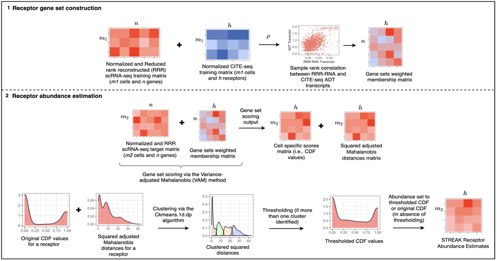

**SPECK Publication**: The accurate estimation of cell surface receptor abundance for single cell transcriptomics data is important for the tasks of cell type and phenotype categorization and cell-cell interaction quantification. Here, we introduce an unsupervised receptor abundance estimation technique named **SPECK (Surface Protein abundance Estimation using CKmeans-based clustered thresholding)** to address the challenges associated with accurate abundance estimation. In this paper, we conclude that SPECK results in improved concordance with Cellular Indexing of Transcriptomes and Epitopes by Sequencing (CITE-seq) data relative to comparative unsupervised abundance estimation techniques using only single-cell RNA-sequencing (scRNA-seq) data.

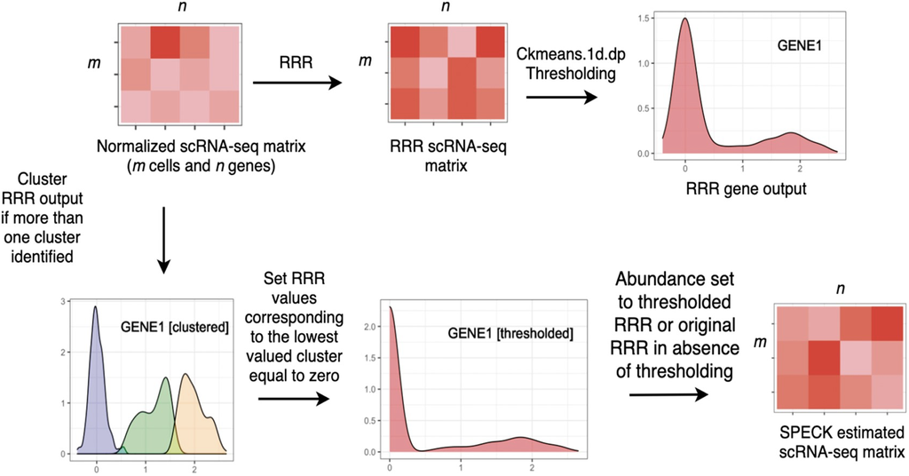

**SCAPE Publication**: Accurate knowledge of cytokine activity levels can be leveraged to provide tailored treatment recommendations based on individual patients’ transcriptomics data. Here, we describe a novel method named Single cell transcriptomics-level Cytokine Activity Prediction and Estimation (SCAPE) that can predict cell-level cytokine activity from scRNA-seq data. SCAPE generates activity estimates using cytokine-specific gene sets constructed using information from the CytoSig and Reactome databases and scored with a modified version of the Variance-adjusted Mahalanobis (VAM) method adjusted for negative weights. Our model has the potential to be incorporated in clinical settings as a way to estimate cytokine signaling for different cell populations within an impacted tissue sample.

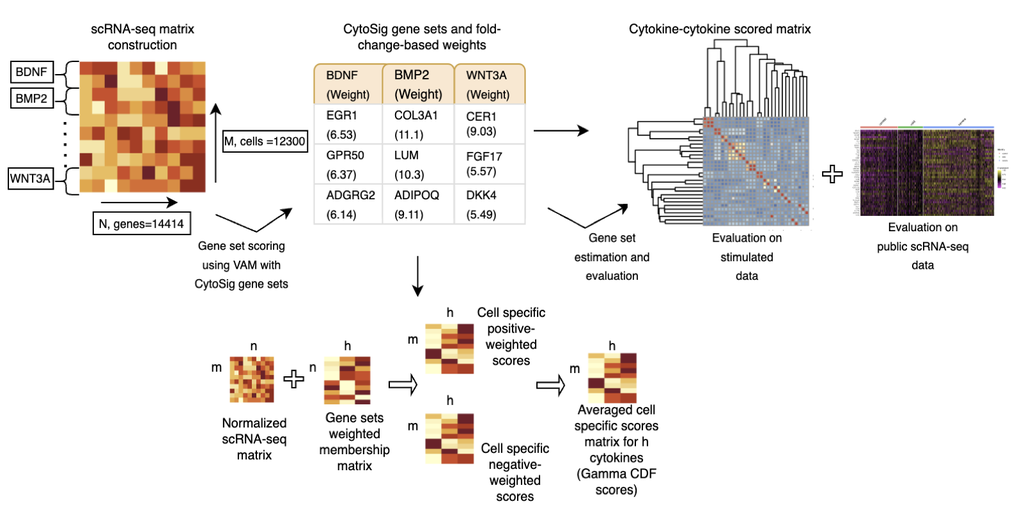